# Party Leadership in the House

My goal with this post is to analyze the relationship between party voting statistics and congressional leadership in the House.

Much of the analysis is elementary, but the project gives me practice with cleaning and manipulating data, as well as with communicating my code and results, which will be of great help to any future academic or data science oriented project.

## Generic Functions

```python
import pickle
import requests
import numpy as np
from sklearn.linear_model import LinearRegression
import matplotlib.pyplot as plt
import pandas as pd
import seaborn as sns
import scipy.stats as stats
import statsmodels.api as sm
from datetime import date
from bs4 import BeautifulSoup
import time
import math
import re

image_path = "../ncrispino.github.io/images/party-leadership-graphs/"

def propublica_data(url):
    return requests.get(url, headers={"X-API-Key": "put_api_key_here"}).json()

def paginated_request(url, num_results):
    """
    Given a url ending with 'offset=', creates a dataframe with the specified number of results (in multiples of 20)
    """
    dfs = []
    for i in range(0, num_results, 20):
        data = propublica_data(url + str(i))
        df = pd.DataFrame(data["results"][0])
        dfs.append(df)
    return pd.concat(dfs)


# Useful functions/definitions
def remove_spines(ax, sides=["top", "right"]):
    """
    Removes spines from all graphs in given axis. Works with an individual axis or list of axes.
    By default removes top and right spines. Returns ax.
    """
    for side in sides:
        try:
            for a in ax:
                a.spines[side].set_visible(False)
        except:
            ax.spines[side].set_visible(False)
    return ax

facecolor=(245/255, 245/255, 245/255)
party_colors = ["royalblue", "r"]
leadership_colors = ["brown", "gold"]

expected_session_end = "2023"
```

## Finding House Congressional Leadership

House data available from Propublica API from Congress 102-117.

```python
def get_congress_members(congress_sessions, chambers=["house", "senate"]):
    congress_members_dfs = []
    for con in congress_sessions:
        for ch in chambers:
            url = f"https://api.propublica.org/congress/v1/{con}/{ch}/members.json"
            df = pd.DataFrame(propublica_data(url)["results"][0]["members"])
            # add column with congressional session
            df["congress"] = con
            congress_members_dfs.append(df)
    congress_members = pd.concat(congress_members_dfs)
    # add new column to congress_members with name of form (last_name, first_name)
    congress_members["full_name"] = congress_members["last_name"] + ", " + congress_members["first_name"]
    return congress_members
```

```python
house_members = get_congress_members(range(102, 118), chambers=["house"]).reset_index(drop=True)
house_members
```

|  | id | title | short_title | api_uri | first_name | middle_name | last_name | suffix | date_of_birth | gender | ... | state | district | at_large | geoid | missed_votes_pct | votes_with_party_pct | votes_against_party_pct | congress | next_election | full_name |
| --- | --- | --- | --- | --- | --- | --- | --- | --- | --- | --- | --- | --- | --- | --- | --- | --- | --- | --- | --- | --- | --- |
| 0 | A000014 | Representative | Rep. | https://api.propublica.org/congress/v1/members... | Neil | None | Abercrombie | None | 1938-06-26 | M | ... | HI | 1 | False | 1501 | 3.22 | 90.10 | 7.28 | 102 | NaN | Abercrombie, Neil |
| 1 | A000022 | Representative | Rep. | https://api.propublica.org/congress/v1/members... | Gary | L. | Ackerman | None | 1942-11-19 | M | ... | NY | 7 | False | 3607 | 18.54 | 92.71 | 4.59 | 102 | NaN | Ackerman, Gary |
| 2 | A000103 | Representative | Rep. | https://api.propublica.org/congress/v1/members... | William | Vollie | Alexander | None | 1934-01-16 | M | ... | AR | 1 | False | 0501 | 20.15 | 88.77 | 8.77 | 102 | NaN | Alexander, William |
| 3 | A000109 | Representative | Rep. | https://api.propublica.org/congress/v1/members... | Wayne | A. | Allard | None | 1943-12-02 | M | ... | CO | 4 | False | 0804 | 1.71 | 84.83 | 11.80 | 102 | NaN | Allard, Wayne |
| 4 | A000121 | Representative | Rep. | https://api.propublica.org/congress/v1/members... | George | Felix | Allen | None | 1952-03-08 | M | ... | VA | 7 | False | 5107 | 0.73 | 86.59 | 10.15 | 102 | NaN | Allen, George |
| ... | ... | ... | ... | ... | ... | ... | ... | ... | ... | ... | ... | ... | ... | ... | ... | ... | ... | ... | ... | ... | ... |
| 7183 | W000809 | Representative | Rep. | https://api.propublica.org/congress/v1/members... | Steve | None | Womack | None | 1957-02-18 | M | ... | AR | 3 | False | 0503 | 0.00 | 94.78 | 4.82 | 117 | 2022 | Womack, Steve |
| 7184 | W000827 | Representative | Rep. | https://api.propublica.org/congress/v1/members... | Ron | None | Wright | None | 1953-04-08 | M | ... | TX | 6 | False | 4806 | 48.39 | 93.33 | 0.00 | 117 | 2022 | Wright, Ron |
| 7185 | Y000062 | Representative | Rep. | https://api.propublica.org/congress/v1/members... | John | None | Yarmuth | None | 1947-11-04 | M | ... | KY | 3 | False | 2103 | 4.35 | 99.17 | 0.41 | 117 | 2022 | Yarmuth, John |
| 7186 | Y000033 | Representative | Rep. | https://api.propublica.org/congress/v1/members... | Don | None | Young | None | 1933-06-09 | M | ... | AK | At-Large | True | 0200 | 12.25 | 86.76 | 12.79 | 117 | 2022 | Young, Don |
| 7187 | Z000017 | Representative | Rep. | https://api.propublica.org/congress/v1/members... | Lee | None | Zeldin | None | 1980-01-30 | M | ... | NY | 1 | False | 3601 | 1.98 | 95.10 | 4.49 | 117 | 2022 | Zeldin, Lee |

7188 rows × 48 columns

Now, isolate members with party leadership roles.

```python
house_leadership = house_members[~house_members["leadership_role"].isna()]
house_leadership
```

|  | id | title | short_title | api_uri | first_name | middle_name | last_name | suffix | date_of_birth | gender | ... | state | district | at_large | geoid | missed_votes_pct | votes_with_party_pct | votes_against_party_pct | congress | next_election | full_name |
| --- | --- | --- | --- | --- | --- | --- | --- | --- | --- | --- | --- | --- | --- | --- | --- | --- | --- | --- | --- | --- | --- |
| 3902 | P000197 | Representative | Rep. | https://api.propublica.org/congress/v1/members... | Nancy | None | Pelosi | None | 1940-03-26 | F | ... | CA | 8 | False | 0608 | 90.50 | 99.42 | 1.16 | 110 | NaN | Pelosi, Nancy |
| 4356 | P000197 | Representative | Rep. | https://api.propublica.org/congress/v1/members... | Nancy | None | Pelosi | None | 1940-03-26 | F | ... | CA | 8 | False | 0608 | 93.40 | 99.06 | 0.00 | 111 | 2010 | Pelosi, Nancy |
| 4805 | P000197 | Representative | Rep. | https://api.propublica.org/congress/v1/members... | Nancy | None | Pelosi | None | 1940-03-26 | F | ... | CA | 8 | False | 0608 | 6.91 | 96.68 | 3.25 | 112 | NaN | Pelosi, Nancy |
| 5491 | D000621 | Representative | Rep. | https://api.propublica.org/congress/v1/members... | Ron | None | DeSantis | None | 1978-09-14 | M | ... | FL | 6 | False | 1206 | 2.42 | 94.70 | 5.22 | 114 | 2016 | DeSantis, Ron |
| 5573 | H000874 | Representative | Rep. | https://api.propublica.org/congress/v1/members... | Steny | H. | Hoyer | None | 1939-06-14 | M | ... | MD | 5 | False | 2405 | 4.00 | 96.90 | 3.02 | 114 | 2016 | Hoyer, Steny |
| ... | ... | ... | ... | ... | ... | ... | ... | ... | ... | ... | ... | ... | ... | ... | ... | ... | ... | ... | ... | ... | ... |
| 7080 | R000588 | Representative | Rep. | https://api.propublica.org/congress/v1/members... | Cedric | None | Richmond | None | 1973-09-13 | M | ... | LA | 2 | False | 2202 | 11.76 | 92.86 | 0.00 | 117 | 2022 | Richmond, Cedric |
| 7099 | S001176 | Representative | Rep. | https://api.propublica.org/congress/v1/members... | Steve | None | Scalise | None | 1965-10-06 | M | ... | LA | 1 | False | 2201 | 1.19 | 99.19 | 0.41 | 117 | 2022 | Scalise, Steve |
| 7135 | S001187 | Representative | Rep. | https://api.propublica.org/congress/v1/members... | Steve | None | Stivers | None | 1965-03-24 | M | ... | OH | 15 | False | 3915 | 10.56 | 92.00 | 7.20 | 117 | 2022 | Stivers, Steve |
| 7162 | V000132 | Representative | Rep. | https://api.propublica.org/congress/v1/members... | Filemon | None | Vela | None | 1963-02-13 | M | ... | TX | 34 | False | 4834 | 2.77 | 98.78 | 0.82 | 117 | 2022 | Vela, Filemon |
| 7184 | W000827 | Representative | Rep. | https://api.propublica.org/congress/v1/members... | Ron | None | Wright | None | 1953-04-08 | M | ... | TX | 6 | False | 4806 | 48.39 | 93.33 | 0.00 | 117 | 2022 | Wright, Ron |

202 rows × 48 columns

It appears that there isn't sufficient House leadership data pre-Congress 115; also, much of the data is empty, as seen below.

```python
house_leadership[["congress", "leadership_role"]].drop_duplicates().head(10)
```

|  | congress | leadership_role |
| --- | --- | --- |
| 3902 | 110 | Speaker of the House |
| 4356 | 111 | Speaker of the House |
| 4805 | 112 | Minority Leader |
| 5491 | 114 |  |
| 5573 | 114 | Minority Whip |
| 5746 | 114 | Speaker of the House |
| 5849 | 115 |  |
| 5909 | 115 | Assistant Leader |
| 5929 | 115 | Caucus Chair |
| 6025 | 115 | Minority Whip |

So, I need another source of data for party leadership. Using [these data](https://github.com/unitedstates/congress-legislators), I will isolate leadership roles for House members.

There seem to be [4 main leadership roles](https://www.house.gov/leadership) for each party in the House, at least in recent times (excluding the Speaker, who we are not including in our analysis as they do not always vote). [Here](http://web.archive.org/web/20170426221833/http://www.house.gov/leadership/) is an example of the leadership when the Republicans are in control, and [here](http://web.archive.org/web/20210604132755/https://www.house.gov/leadership) is an example when the Democrats are in control. More leadership roles exist in the House, however I will be assuming these are the most important roles due to their presence in the "leadership" tab of the House website.

For the Democrats, leadership roles are as follows, with the titles for the majority party first, then titles for the minority party in parentheses (same name if no parentheses):

- Majority Leader (Democratic Leader)
- Majority Whip (Democratic Whip)
- Assistant Speaker (Assistant Democratic Leader)
- Democratic Caucus Chairman

For the Republicans, they are as follows, this time with the titles for the minority party first, then titles for the majority party in parentheses (same name if no parentheses):

- Republican Leader (Majority Leader)
- Republican Whip (Majority Whip)
- Republican Conference Chairman
- Republican Policy Committee Chairman

I find no easy database or api with all the information, so I'll scrape from the House's [website](https://history.house.gov/People/).

```python
def house_table(url):
    """
    Given link specifying a leadership position from US House's website (found on https://history.house.gov/People/),
    scrapes table and puts into a pandas df.
    """
    site = requests.get(url)
    soup = BeautifulSoup(site.text, "lxml")
    table = soup.find("table", {"id": "tblSort"})
    headers = []
    rows = []
    for th in table.find_all("th"):
        headers.append(th.text)
    for tr in table.tbody.find_all("tr"):
        curr_row = []
        for td in tr.find_all("td"):
            curr_row.append(td.text.strip())
        rows.append(curr_row)
    return pd.DataFrame(rows, columns=headers)

# find valid positions on House website
positions = ["Majority-Leaders", "Minority-Leaders", "Democratic-Whips", "Republican-Whips",
                 "Democratic-Caucus-Chairmen", "Republican-Conference-Chairmen"]
leadership_dfs = []
for position in positions:
    url = f"https://history.house.gov/People/Office/{position}/"
    df = house_table(url)
    # add column indicating role
    df["leadership_role"] = position
    leadership_dfs.append(df)
```

Combine into one dataframe for ease of analysis.

```python
house_leaders_df = pd.concat(leadership_dfs)
house_leaders_df
```

|  | Congress and Years | Name | Party | State or Territory | leadership_role |
| --- | --- | --- | --- | --- | --- |
| 0 | 56th (1899–1901) | PAYNE, Sereno Elisha | Republican | NY | Majority-Leaders |
| 1 | 57th (1901–1903) | PAYNE, Sereno Elisha | Republican | NY | Majority-Leaders |
| 2 | 58th (1903–1905) | PAYNE, Sereno Elisha | Republican | NY | Majority-Leaders |
| 3 | 59th (1905–1907) | PAYNE, Sereno Elisha | Republican | NY | Majority-Leaders |
| 4 | 60th (1907–1909) | PAYNE, Sereno Elisha | Republican | NY | Majority-Leaders |
| ... | ... | ... | ... | ... | ... |
| 77 | 114th (2015–2017) | MCMORRIS RODGERS, Cathy | NaN | WA | Republican-Conference-Chairmen |
| 78 | 115th (2017–2019) | MCMORRIS RODGERS, Cathy | NaN | WA | Republican-Conference-Chairmen |
| 79 | 116th (2019–2021) | CHENEY, Liz | NaN | WY | Republican-Conference-Chairmen |
| 80 | 117th (2021–2023) | CHENEY, Liz 5 | NaN | WY | Republican-Conference-Chairmen |
| 81 | 117th (2021–2023) | STEFANIK, Elise M. 6 | NaN | NY | Republican-Conference-Chairmen |

428 rows × 5 columns

Remove unnecessary capitalization and numbers from the "Name" column.

```python
def standardize_name(x):
    """
    Removes numbers at the end of names (corresponding to superscripts in House website data)
    and removes unnecessary capitalization.
    """
    return re.sub(r"[0-9]+$", "", x).strip().title()
# house_leaders_df["Name"] = house_leaders_df["Name"].apply(standardize_name)

def last_first_names(x):
    """
    Removes middle names and replaces firstname with nickname if applicable (as Propublica API uses nicknames)
    """
#     print(x)
    lastname = re.findall(r"^[a-zA-Z'-]+", x)[0].title()
    firstname = re.findall(r",\s([a-zA-Z'-]+)", x)[0]
    nickname = re.findall(r"\([a-zA-Z\s\.]+\)$", x)
    if len(nickname) == 0:
        return lastname + ", " + firstname
    # get nickname and remove parens and spaces
    nickname_use = re.sub(r"\s", "", nickname[0][1:-1])
    return lastname + ", " + nickname_use

house_leaders_df["Name"] = house_leaders_df["Name"].apply(last_first_names)
house_leaders_df.head()
```

|  | Congress and Years | Name | Party | State or Territory | leadership_role |
| --- | --- | --- | --- | --- | --- |
| 0 | 56th (1899–1901) | Payne, Sereno | Republican | NY | Majority-Leaders |
| 1 | 57th (1901–1903) | Payne, Sereno | Republican | NY | Majority-Leaders |
| 2 | 58th (1903–1905) | Payne, Sereno | Republican | NY | Majority-Leaders |
| 3 | 59th (1905–1907) | Payne, Sereno | Republican | NY | Majority-Leaders |
| 4 | 60th (1907–1909) | Payne, Sereno | Republican | NY | Majority-Leaders |

Split Congress and Years into two columns.

```python
def get_session(x):
    return int(re.findall(r"^[0-9]+", x)[0])
def get_year(x, idx):
    # note: needed special hyphen "–", which I copied and pasted from a line in the df (different from standard hyphen "-")
    return re.findall(r"([0-9]+)–([0-9]+)", x)[0][idx]
house_leaders_df["congress"] = house_leaders_df["Congress and Years"].apply(get_session)
house_leaders_df["start_year"] = house_leaders_df["Congress and Years"].apply(get_year, args=[0])
house_leaders_df["end_year"] = house_leaders_df["Congress and Years"].apply(get_year, args=[1])
```

```python
# need to take a copy of the slice because later I will be assigning other values to the "Name" column;
# this avoids the infamous SettingWithCopyWarning
house_leaders_available = house_leaders_df[house_leaders_df["congress"] >= 102].copy()
house_leaders_available.head()
```

|  | Congress and Years | Name | Party | State or Territory | leadership_role | congress | start_year | end_year |
| --- | --- | --- | --- | --- | --- | --- | --- | --- |
| 49 | 102nd (1991–1993) | Gephardt, Richard | Democrat | MO | Majority-Leaders | 102 | 1991 | 1993 |
| 50 | 103rd (1993–1995) | Gephardt, Richard | Democrat | MO | Majority-Leaders | 103 | 1993 | 1995 |
| 51 | 104th (1995–1997) | Armey, Richard | Republican | TX | Majority-Leaders | 104 | 1995 | 1997 |
| 52 | 105th (1997–1999) | Armey, Richard | Republican | TX | Majority-Leaders | 105 | 1997 | 1999 |
| 53 | 106th (1999–2001) | Armey, Richard | Republican | TX | Majority-Leaders | 106 | 1999 | 2001 |

Standardize names in `house_members` df as well (e.g., change "DeLay" to "Delay" as done in `house_leaders`), though make a copy instead of doing it directly to the df.

```python
# make alternate house_members df with changed names (so as to be "Mcmorris" instead of "McMorris") but don't alter orig df
house_members_altnames = house_members.copy()
house_members_altnames["full_name"] = house_members_altnames["full_name"].str.title()
```

### Find Propublica API id for each representative.

First, see which names from House website aren't in the Propublica API's list of House members.

```python
house_leaders_available[~house_leaders_available["Name"].isin(house_members_altnames["full_name"].values)]
```

|  | Congress and Years | Name | Party | State or Territory | leadership_role | congress | start_year | end_year |
| --- | --- | --- | --- | --- | --- | --- | --- | --- |
| 50 | 102nd (1991–1993) | Gingrich, Newton | NaN | GA | Republican-Whips | 102 | 1991 | 1993 |
| 51 | 103rd (1993–1995) | Gingrich, Newton | NaN | GA | Republican-Whips | 103 | 1993 | 1995 |
| 68 | 104th (1995–1997) | Fazio, Victor | NaN | CA | Democratic-Caucus-Chairmen | 104 | 1995 | 1997 |
| 69 | 105th (1997–1999) | Fazio, Victor | NaN | CA | Democratic-Caucus-Chairmen | 105 | 1997 | 1999 |
| 70 | 106th (1999–2001) | Frost, Jonas | NaN | TX | Democratic-Caucus-Chairmen | 106 | 1999 | 2001 |
| 71 | 107th (2001–2003) | Frost, Jonas | NaN | TX | Democratic-Caucus-Chairmen | 107 | 2001 | 2003 |
| 76 | 113th (2013–2015) | Mcmorris, Cathy | NaN | WA | Republican-Conference-Chairmen | 113 | 2013 | 2015 |
| 77 | 114th (2015–2017) | Mcmorris, Cathy | NaN | WA | Republican-Conference-Chairmen | 114 | 2015 | 2017 |
| 78 | 115th (2017–2019) | Mcmorris, Cathy | NaN | WA | Republican-Conference-Chairmen | 115 | 2017 | 2019 |

From Google, "Mcmorris, Cathy" refers to "McMorris Rodgers, Cathy". All other names not in `house_leaders_available` df are found by last name in `house_members` (but not using last_name to sort on its own because there could be multiple members with same last name).

```python
house_members_altnames.set_index("last_name").loc[["Gingrich", "Fazio", "Frost", "Watts", "McMorris Rodgers"], :].drop_duplicates("full_name")
```

| last_name | id | title | short_title | api_uri | first_name | middle_name | suffix | date_of_birth | gender | party | ... | state | district | at_large | geoid | missed_votes_pct | votes_with_party_pct | votes_against_party_pct | congress | next_election | full_name |
| --- | --- | --- | --- | --- | --- | --- | --- | --- | --- | --- | --- | --- | --- | --- | --- | --- | --- | --- | --- | --- | --- |
| Gingrich | G000225 | Representative | Rep. | https://api.propublica.org/congress/v1/members... | Newt | None | None | 1943-06-17 | M | R | ... | GA | 6 | False | 1306 | 9.97 | 89.74 | 6.96 | 102 | NaN | Gingrich, Newt |
| Fazio | F000053 | Representative | Rep. | https://api.propublica.org/congress/v1/members... | Vic | None | None | 1942-10-11 | M | D | ... | CA | 4 | False | 0604 | 3.22 | 89.40 | 7.75 | 102 | NaN | Fazio, Vic |
| Frost | F000392 | Representative | Rep. | https://api.propublica.org/congress/v1/members... | Martin | None | None | 1942-01-01 | M | D | ... | TX | 24 | False | 4824 | 8.15 | 90.37 | 7.46 | 102 | NaN | Frost, Martin |
| Watts | W000210 | Representative | Rep. | https://api.propublica.org/congress/v1/members... | J.C. | None | None | 1957-11-18 | M | R | ... | OK | 4 | False | 4004 | 4.98 | 95.33 | 5.90 | 104 | NaN | Watts, J.C. |
| McMorris Rodgers | M001159 | Representative | Rep. | https://api.propublica.org/congress/v1/members... | Cathy | None | None | 1969-05-22 | F | R | ... | WA | 5 | False | 5305 | 2.55 | 96.22 | 4.03 | 109 | NaN | Mcmorris Rodgers, Cathy |

5 rows × 47 columns

Manually alter names scraped from website to match those in Propublica API.

```python
names_and_replacements = [("Gingrich, Newton", "Gingrich, Newt"),
                          ("Fazio, Victor", "Fazio, Vic"),
                          ("Frost, Jonas", "Frost, Martin"),
                          ("Watts, J", "Watts, J.C."),
                          # not "McMorris Rodgers" because str.title operation applied
                          ("Mcmorris, Cathy", "Mcmorris Rodgers, Cathy")]
for nr in names_and_replacements:
    replaced_df = house_leaders_available.loc[:, "Name"].replace(nr[0], nr[1])
    house_leaders_available.loc[:, "Name"] = replaced_df
house_leaders_available["Name"]
```

```
49          Gephardt, Richard
50          Gephardt, Richard
51             Armey, Richard
52             Armey, Richard
53             Armey, Richard
               ...
77    Mcmorris Rodgers, Cathy
78    Mcmorris Rodgers, Cathy
79                Cheney, Liz
80                Cheney, Liz
81            Stefanik, Elise
Name: Name, Length: 104, dtype: object
```

Now, check again if all names in `house_leaders_available` are in `house_members` (which is true if the below is empty).

```python
house_leaders_available[~house_leaders_available["Name"].isin(house_members_altnames["full_name"].values)]
```

|  | Congress and Years | Name | Party | State or Territory | leadership_role | congress | start_year | end_year |
| --- | --- | --- | --- | --- | --- | --- | --- | --- |

Now, merge `house_members` df from ProPublica API with the leadership roles scraped from the House website.

```python
# drop leadership_role column from house_members df because API doesn't have all the leadership roles
house_leaders_merged = (house_leaders_available.merge(house_members_altnames.drop(columns="leadership_role"),
                                                      left_on=["Name", "congress"],
                                                      right_on=["full_name", "congress"]))
print(len(house_leaders_available))
print(len(house_leaders_merged))
```

```
104
104
```

Because the length of `house_leaders_available` and `house_leaders_merged` are the same, all House leaders scraped from the tables in the House website for Congress 102-117 have been accounted for.

Before I move on, I'll make a df that only counts each party leader once so that the aggregate values for leaders aren't skewed. Currently, if a party leader has more than one role during a congressional session, they would be counted twice in the mean. When used, the below df will address this problem.

```python
house_leaders_one = house_leaders_merged.groupby(["Name", "congress"], as_index=False).first()
```

Also, I'll make a df called `house_never_leaders` with all House members who have yet to serve in leadership role in any congressional session, and I'll make another df called `house_no_leaders` with all House members who weren't serving in a leadership role in the given congressional session.

```python
house_never_leaders = house_members_altnames[~house_members_altnames["full_name"].isin(house_leaders_merged["Name"].values)]
house_no_leaders = (house_leaders_one[["Name", "congress"]]
                    .merge(house_members_altnames.rename(columns={"full_name": "Name"}), on=["Name", "congress"],
                           how="outer", indicator=True)
                    .query("_merge == 'right_only'"))
```

## Comparing Voting Statistics Among Leaders

Before starting, note that percent votes for or against one's party represents the percentage of votes a given member of congress voted for or against the majority of their party.

For example, from [Propublica](https://projects.propublica.org/represent/members/W000817/votes-against-party/116), the votes against party percent of Sen. Warren would be 21.2% in the 116th Congress: "Sen. Warren voted against a majority of Senate Democrats 92 times (21.2%) in the 116th Congress (2019-20)."

### Distribution of % Votes Against Party for Leadership and Non-Leadership

For each party, get all leadership % votes against party, then plot with histogram to see the distribution.

```python
all_lead_votes_dem = house_leaders_one.query("party == 'D'")["votes_against_party_pct"]
all_lead_votes_rep = house_leaders_one.query("party == 'R'")["votes_against_party_pct"]
```

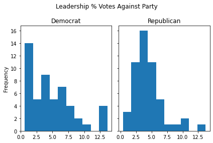

```python
fig, ax = plt.subplots(1, 2, sharey=True)
all_lead_votes_dem.plot(ax=ax[0], kind="hist", title="Democrat", bins=10)
all_lead_votes_rep.plot(ax=ax[1], kind="hist", title="Republican", bins=10)
fig.suptitle("Leadership % Votes Against Party")
fig.tight_layout()
```

For Democratic leadership, having a lower (~0) % vote against party is more common, while for Republican leadership, it's more common to be around the 2-6% range.

For each party, get all non-leadership % votes against party, then plot with histogram to see the distribution. We define non-leadership as all members not holding a leadership role in a given session.

```python
all_votes_dem = house_no_leaders.query("party == 'D'")["votes_against_party_pct"]
all_votes_rep = house_no_leaders.query("party == 'R'")["votes_against_party_pct"]
```

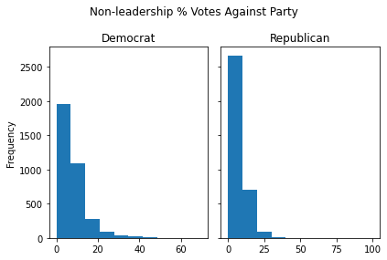

```python
fig, ax = plt.subplots(1, 2, sharey=True)
all_votes_dem.plot(ax=ax[0], kind="hist", title="Democrat", bins=10)
all_votes_rep.plot(ax=ax[1], kind="hist", title="Republican", bins=10)
fig.suptitle("Non-leadership % Votes Against Party")
fig.tight_layout()
```

Both parties seem similar, though Republicans seem a bit stronger as a party, due to their high frequency of very low % votes against party.

*Note that there is (likely) incorrect data from Propublica w/ a Republican voting against their party 100% of the time, but this won't really affect our analysis.*

### Percent Votes with Party and Sessions in Leadership

See if voting with party is correlated with the number of sessions of leadership positions held.

Exclude those still serving in leadership in session 117 as they could have more sessions left in leadership.

```python
house_leaders_117 = house_leaders_one.query("congress == 117")
house_leaders_no_117 = house_leaders_one[~house_leaders_one["Name"].isin(house_leaders_117["Name"].values)]
```

```python
avg_party_votes = house_leaders_no_117.groupby("Name").mean()["votes_with_party_pct"].rename("Average Percent Votes with Party")
total_leadership_sessions = house_leaders_one.groupby("Name").count()["votes_with_party_pct"].rename("Number of Sessions in Leadership")
party_votes_and_sessions = pd.merge(avg_party_votes, total_leadership_sessions, on="Name")
party_votes_and_sessions.head()
```

| Name | Average Percent Votes with Party | Number of Sessions in Leadership |
| --- | --- | --- |
| Armey, Richard | 94.594000 | 5 |
| Becerra, Xavier | 96.600000 | 2 |
| Blunt, Roy | 96.576667 | 3 |
| Boehner, John | 96.606000 | 5 |
| Bonior, David | 90.590000 | 6 |

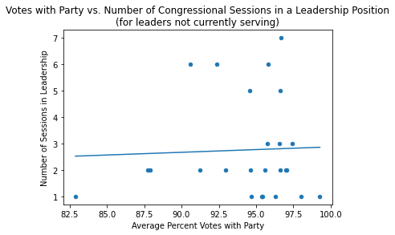

```python
fig, ax = plt.subplots()
party_votes_and_sessions.plot(ax=ax, kind="scatter", x=0, y=1)
ax.set_title("Votes with Party vs. Number of Congressional Sessions in a Leadership Position\n(for leaders not currently serving)")
X = party_votes_and_sessions.iloc[:, 0].values
y = party_votes_and_sessions.iloc[:, 1].values
# quick line of best fit from below link
# "https://stackoverflow.com/questions/22239691/code-for-best-fit-straight-line-of-a-scatter-plot-in-python"
ax.plot(np.unique(X), np.poly1d(np.polyfit(X, y, 1))(np.unique(X)))
```

This line of best fit shows a slight positive relationship, with a regression coefficient of 0.0292 as seen below.

```python
mod = sm.OLS(y, X)
res = mod.fit()
print(res.summary())
```

```
                                 OLS Regression Results
=======================================================================================
Dep. Variable:                      y   R-squared (uncentered):                   0.688
Model:                            OLS   Adj. R-squared (uncentered):              0.675
Method:                 Least Squares   F-statistic:                              52.91
Date:                Mon, 23 Aug 2021   Prob (F-statistic):                    1.63e-07
Time:                        22:27:51   Log-Likelihood:                         -50.981
No. Observations:                  25   AIC:                                      104.0
Df Residuals:                      24   BIC:                                      105.2
Df Model:                           1
Covariance Type:            nonrobust
==============================================================================
                 coef    std err          t      P>|t|      [0.025      0.975]
------------------------------------------------------------------------------
x1             0.0292      0.004      7.274      0.000       0.021       0.038
==============================================================================
Omnibus:                        4.739   Durbin-Watson:                   2.107
Prob(Omnibus):                  0.094   Jarque-Bera (JB):                4.165
Skew:                           0.978   Prob(JB):                        0.125
Kurtosis:                       2.585   Cond. No.                         1.00
==============================================================================

Notes:
[1] R² is computed without centering (uncentered) since the model does not contain a constant.
[2] Standard Errors assume that the covariance matrix of the errors is correctly specified.
```

Looking purely at the regression coefficient, an increase in 1 percentage point of the votes with party would increase the number of sessions in leadership, on average, by 0.0292 sessions. However, one would need to increase their percentage votes with party by a fairly large amount (by $>10\%$) for an impact to be felt on their time in leadership roles. Thus while there's a small positive correlation—meaning voting more with the party could have an impact—it is too small be very meaningful, even though the coefficient is statistically significant. However, there are many covariates and more observations that would need to be present to run a valid regression analysis. This analysis shows there is some measure of direct correlation, which may prompt further research questions.

### Does Party Leadership Vote More with Their Party (on avg)?

In our case, votes against are easier to visualize. So, rephrasing the question, does party leadership vote less against their party (on avg)?

First, get avg % votes with party for party leadership by party and session and merge with df containing avg % for all non-leadership House members. Then, plot by party.

```python
leadership_avg_party_votes = house_leaders_one.groupby(["congress", "party"]).mean()["votes_against_party_pct"].rename("leadership_votes_against_party_pct")
nonlead_avg_party_votes = (house_no_leaders.groupby(["congress", "party"]).mean()["votes_against_party_pct"]
                           .rename("nonleadership_votes_against_party_pct")
                           .to_frame().query("party == 'D' or party == 'R'"))
leadership_and_non_avg = pd.merge(leadership_avg_party_votes, nonlead_avg_party_votes, on=["congress", "party"])
leadership_and_non_avg.head()
```

| congress | party | leadership_votes_against_party_pct | nonleadership_votes_against_party_pct |
| --- | --- | --- | --- |
| 102 | D | 4.745000 | 10.847068 |
|  | R | 10.563333 | 15.234371 |
| 103 | D | 6.973333 | 11.288664 |
|  | R | 8.763333 | 12.897584 |
| 104 | D | 10.336667 | 16.269463 |

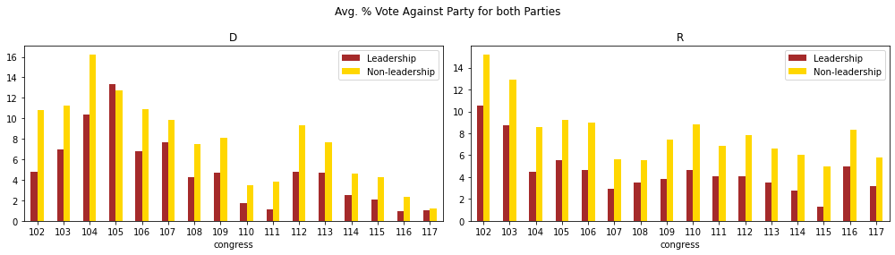

```python
fig, ax = plt.subplots(1, 2, figsize=(14, 4))
for i, p in enumerate(["D", "R"]):
    (leadership_and_non_avg.loc[pd.IndexSlice[:, p], :].reset_index("party", drop=True)
    .plot(ax=ax[i], kind="bar", title=p, rot=0, color=leadership_colors))
    ax[i].legend(["Leadership", "Non-leadership"])
fig.suptitle("Avg. % Vote Against Party for both Parties")
fig.tight_layout()
```

So, it seems party leadership generally votes less against their party. In fact, only in session 105 is the avg % votes against party for Democratic leadership greater than the average of the entire party.

But by how much?

### Difference in % Vote Against Party between leaders and non-leaders

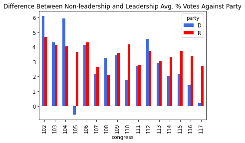

```python
leadership_diff = leadership_and_non_avg["nonleadership_votes_against_party_pct"] - leadership_and_non_avg["leadership_votes_against_party_pct"]
fig, ax = plt.subplots()
leadership_diff
(leadership_diff.reset_index()
 .pivot(index="congress", columns="party", values=0)
 .plot(ax=ax, kind="bar", title="Difference Between Non-leadership and Leadership Avg. % Votes Against Party", color=party_colors))
```

```python
leadership_diff[leadership_diff <= 0]
```

```
congress  party
105       D       -0.578696
dtype: float64
```

So, only in one session does leadership—on average—vote more against their party.

### Worst Party Leadership

Defined as those who voted least with party. By calling them the "worst", I am not making any moral judgement; some of our best representatives may have been those who voted most against their party. However, to add a little fun into this analysis, I will be retaining the title "worst" as a placeholder for representatives with the highest % vote against party.

```python
worst_leaders_sess = (house_leaders_merged
                      .loc[house_leaders_merged.groupby(["congress", "party"])["votes_against_party_pct"].idxmax(),
                           ["Name", "votes_against_party_pct", "congress", "party"]]
                      .set_index(["congress", "party"]))
```

Find each session's average among all members.

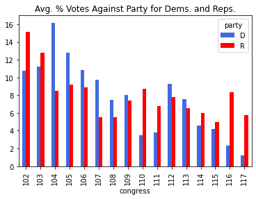

```python
fig, ax = plt.subplots()
all_avg_party_votes = (house_members_altnames.groupby(["congress", "party"]).mean()
                       .loc[pd.IndexSlice[:, ["D", "R"]], "votes_against_party_pct"]).rename("avg_votes_against_party_pct")
all_avg_party_votes_plot = all_avg_party_votes.reset_index().pivot(index="congress", columns="party", values="avg_votes_against_party_pct")
all_avg_party_votes_plot.plot(ax=ax, kind="bar", color=party_colors, title="Avg. % Votes Against Party for Dems. and Reps.")
```

Combine party's avg % votes against party with the "worst" leaders' % in each session. Because we're comparing the % average to the % of only one member, we don't need to exclude that member's voting % from the calculation of the average.

```python
worst_leaders_compare = worst_leaders_sess.merge(all_avg_party_votes, on=["congress", "party"], how="left").set_index("Name", append=True)
```

Find the difference in % votes for each of the "worst" leaders with the avg. of their party.

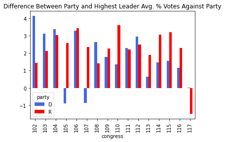

```python
worst_leaders_diff = worst_leaders_compare["avg_votes_against_party_pct"] - worst_leaders_compare["votes_against_party_pct"]
fig, ax = plt.subplots()
worst_leaders_diff
(worst_leaders_diff.reset_index("Name", drop=True).reset_index()
 .pivot(index="congress", columns="party", values=0)
 .plot(ax=ax, kind="bar", title="Difference Between Party and Highest Leader Avg. % Votes Against Party", color=party_colors))
```

So, there are only three sessions in which even the "worst" leader votes against their party at a higher rate than the average of all party members. Even then, it's by less than one and a half percent. Thus even the "worst" leaders are representative of their party.

```python
worst_leaders_diff[worst_leaders_diff <= 0]
```

```
congress  party  Name
105       D      Bonior, David   -0.877095
107       D      Bonior, David   -0.855305
117       R      Cheney, Liz     -1.482300
dtype: float64
```

### Does Leadership Vote Differently in their Last Sessions?

Exlude those still serving in session 117, as we don't know their last session.

```python
last_sessions = house_leaders_no_117.groupby("Name")["congress"].max()
last_sessions_ls = []
for tp in last_sessions.iteritems():
    last_sessions_ls.append(tp)
last_sessions_votes = house_leaders_no_117.set_index(["Name", "congress"]).loc[last_sessions_ls, "votes_with_party_pct"]
last_sessions_votes.head()
```

```
Name             congress
Armey, Richard   107         97.48
Becerra, Xavier  114         96.84
Blunt, Roy       110         95.80
Boehner, John    111         96.35
Bonior, David    107         89.86
Name: votes_with_party_pct, dtype: float64
```

Now, for each member plot the difference between their last session's % votes with party and the avg % votes with party (excluding the % for their last session).

```python
non_last_sessions_votes = house_leaders_no_117.set_index(["Name", "congress"])[~house_leaders_no_117.set_index(["Name", "congress"])["votes_with_party_pct"].isin(last_sessions_votes)]["votes_with_party_pct"]
non_last_sessions_avg = non_last_sessions_votes.groupby(["Name"]).mean()
non_last_sessions_avg.head()
```

```
Name
Armey, Richard     93.8725
Becerra, Xavier    96.3600
Blunt, Roy         96.9650
Boehner, John      96.6700
Bonior, David      90.7360
Name: votes_with_party_pct, dtype: float64
```

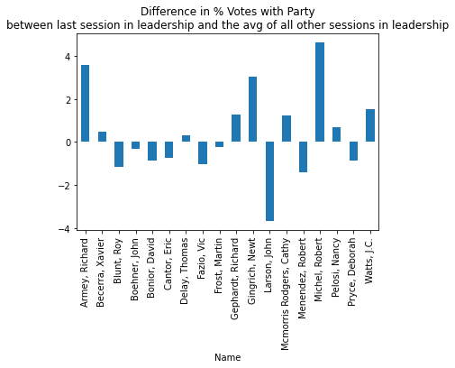

```python
fig, ax = plt.subplots()
# drop NaN because there could be leaders who only served one session in a leadership role
last_sessions_diff = (last_sessions_votes - non_last_sessions_avg).dropna()
last_sessions_diff.reset_index("congress", drop=True).plot(ax=ax, kind="bar", title="Difference in % Votes with Party\nbetween last session in leadership and the avg of all other sessions in leadership")
```

```python
print((last_sessions_diff >= 0).sum())
print((last_sessions_diff < 0).sum())
```

```
9
9
```

So, there are an equal number of leaders who voted more with their party and less with their party in their last leadership session compared to all their other leadership sessions.

### Avg % Vote with Party for Last vs. Non-last Sessions

Now, make a graph with avg last session in leadership % vote with party and avg non-last sessions leadership % vote with party. This will allow us to see how much the average vote with party differs between member of congress' last leadership session and their other sessions. This is not split by party as many sessions don't have leaders for which it is their last session.

*Note: Some leaders will not be leaving politics but will rather be 'moving up' into more important positions. For example, Nancy Pelosi is included in the dfs below but has since become Speaker of the House.*

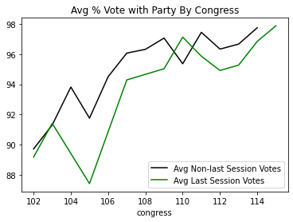

```python
fig, ax = plt.subplots()
non_last_sessions_votes.rename("Avg Non-last Session Votes").groupby("congress").mean().plot(ax=ax, color="black")
last_sessions_votes.rename("Avg Last Session Votes").groupby("congress").mean().plot(ax=ax, color="green")
ax.legend()
ax.set_title("Avg % Vote with Party By Congress")
```

So, it appears that, on aggregate, House leadership usually votes less with their party during their last leadership session.

### Avg % Vote with Party by Years in Leadership:

See how the avg % vote with party differs by each subsequent year in a leadership position across congressional sessions.

Get the number of session in leadership for each congressional session (e.g., if 103 is the first session in leadership served, it corresponds with 1; 104 corresponds with 2, etc.) first by sorting by session then by using cumcount.

```python
yearly_leader_votes = house_leaders_one.set_index("Name")[["congress", "party", "votes_with_party_pct"]].join(total_leadership_sessions)
```

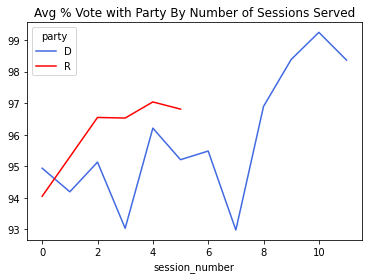

```python
yearly_leader_votes = yearly_leader_votes.sort_values("congress")
yearly_leader_votes = yearly_leader_votes.assign(session_number=yearly_leader_votes.groupby(["Name"])["congress"].cumcount())
fig, ax = plt.subplots()
(yearly_leader_votes.groupby(["session_number", "party"])["votes_with_party_pct"].mean()
 .to_frame().pivot_table(index="session_number", columns="party", values="votes_with_party_pct")
 .plot(ax=ax, title="Avg % Vote with Party By Number of Sessions Served", color=party_colors))
```

For Republicans, on average, there's a rise in % vote with party the more sessions served in leadership. For Democrats, there's no clear pattern.

## What This Means

This project isn't too informative, but has helped me prepare for future projects well, where I can implement the statistical analyses I have learned in school to make useful conclusions. Unlike past projects, making the graphs presentable wasn't my focus and much of the interpretation I have left up to the reader. However, this time I used Jupyter Notebook to house (haha) my post, so the reader could glimpse my thought process and methods. As a disclaimer, some of the graphs I created may not be useful or may actually be misguiding, and my coding may be done in inefficient ways. I also cannot certify all my data is correct and caution drawing conclusions beyond the sessions and leadership positions explicitly identified.

A brief note before I end: I have also isolated Senate leadership positions and done the same kind of elementary analysis with them; perhaps I'll share that in the future with more riveting analysis.

Thanks for reading!